```python
# Obaid Ur Rehman
```

```python
%matplotlib inline
```

```python
import pandas as pd  #importing pandas
import numpy as np
import matplotlib
```

# 1. Load the dataset to pandas dataframe and print names of columns¶

```python
ckdf = pd.read_csv("Assignment Material/Dataset/chronic_kidney_disease_full.csv")
```

```python
ckdf[['age', 'bp', 'sg', 'al', 'su', 'rbc', 'pc', 'pcc', 'ba', 'bgr', 'bu', 'sc', 'sod', 'pot', 'hemo', 'pcv', 'wbcc', 'rbcc', 'htn', 'dm', 'cad', 'appet', 'pe', 'ane', 'class']]
```

|  | age | bp | sg | al | su | rbc | pc | pcc | ba | bgr | ... | pcv | wbcc | rbcc | htn | dm | cad | appet | pe | ane | class |
| --- | --- | --- | --- | --- | --- | --- | --- | --- | --- | --- | --- | --- | --- | --- | --- | --- | --- | --- | --- | --- | --- |
| 0 | NaN | NaN | NaN | NaN | NaN | NaN | NaN | NaN | NaN | NaN | ... | NaN | NaN | NaN | NaN | NaN | NaN | NaN | NaN | NaN | NaN |
| 1 | 48.0 | 80.0 | 1.020 | 1.0 | 0.0 | NaN | normal | notpresent | notpresent | 121.0 | ... | 44.0 | 7800.0 | 5.2 | yes | ?yes | no | good | no | no | ckd |
| 2 | 7.0 | 50.0 | 1.020 | 4.0 | 0.0 | NaN | normal | notpresent | notpresent | NaN | ... | 38.0 | 6000.0 | NaN | no | no | no | good | no | no | ckd |
| 3 | 62.0 | 80.0 | 1.010 | 2.0 | 3.0 | normal | normal | notpresent | notpresent | 423.0 | ... | 31.0 | 7500.0 | NaN | no | yes | no | poor | no | yes | ckd |
| 4 | 48.0 | 70.0 | 1.005 | 4.0 | 0.0 | normal | abnormal | present | notpresent | 117.0 | ... | 32.0 | 6700.0 | 3.9 | yes | no | no | poor | yes | yes | ckd |
| 5 | 51.0 | 80.0 | 1.010 | 2.0 | 0.0 | normal | normal | notpresent | notpresent | 106.0 | ... | 35.0 | 7300.0 | 4.6 | no | no | no | good | no | no | ckd |
| 6 | 60.0 | 90.0 | 1.015 | 3.0 | 0.0 | NaN | NaN | notpresent | notpresent | 74.0 | ... | 39.0 | 7800.0 | 4.4 | yes | yes | no | good | yes | no | ckd |
| 7 | 68.0 | 70.0 | 1.010 | 0.0 | 0.0 | NaN | normal | notpresent | notpresent | 100.0 | ... | 36.0 | NaN | NaN | no | no | no | good | no | no | ckd |
| 8 | 24.0 | NaN | 1.015 | 2.0 | 4.0 | normal | abnormal | notpresent | notpresent | 410.0 | ... | 44.0 | 6900.0 | 5.0 | no | yes | no | good | yes | no | ckd |
| 9 | 52.0 | 100.0 | 1.015 | 3.0 | 0.0 | normal | abnormal | present | notpresent | 138.0 | ... | 33.0 | 9600.0 | 4.0 | yes | yes | no | good | no | yes | ckd |
| 10 | 53.0 | 90.0 | 1.020 | 2.0 | 0.0 | abnormal | abnormal | present | notpresent | 70.0 | ... | 29.0 | 12100.0 | 3.7 | yes | yes | no | poor | no | yes | ckd |
| 11 | 50.0 | 60.0 | 1.010 | 2.0 | 4.0 | NaN | abnormal | present | notpresent | 490.0 | ... | 28.0 | NaN | NaN | yes | yes | no | good | no | yes | ckd |
| 12 | 63.0 | 70.0 | 1.010 | 3.0 | 0.0 | abnormal | abnormal | present | notpresent | 380.0 | ... | 32.0 | 4500.0 | 3.8 | yes | yes | no | poor | yes | no | ckd |
| 13 | 68.0 | 70.0 | 1.015 | 3.0 | 1.0 | NaN | normal | present | notpresent | 208.0 | ... | 28.0 | 12200.0 | 3.4 | yes | yes | yes | poor | yes | no | ckd |
| 14 | 68.0 | 70.0 | NaN | NaN | NaN | NaN | NaN | notpresent | notpresent | 98.0 | ... | NaN | NaN | NaN | yes | yes | yes | poor | yes | no | ckd |
| 15 | 68.0 | 80.0 | 1.010 | 3.0 | 2.0 | normal | abnormal | present | present | 157.0 | ... | 16.0 | 11000.0 | 2.6 | yes | yes | yes | poor | yes | no | ckd |
| 16 | 40.0 | 80.0 | 1.015 | 3.0 | 0.0 | NaN | normal | notpresent | notpresent | 76.0 | ... | 24.0 | 3800.0 | 2.8 | yes | no | no | good | no | yes | ckd |
| 17 | 47.0 | 70.0 | 1.015 | 2.0 | 0.0 | NaN | normal | notpresent | notpresent | 99.0 | ... | NaN | NaN | NaN | no | no | no | good | no | no | ckd |
| 18 | 47.0 | 80.0 | NaN | NaN | NaN | NaN | NaN | notpresent | notpresent | 114.0 | ... | NaN | NaN | NaN | yes | no | no | poor | no | no | ckd |
| 19 | 60.0 | 100.0 | 1.025 | 0.0 | 3.0 | NaN | normal | notpresent | notpresent | 263.0 | ... | 37.0 | 11400.0 | 4.3 | yes | yes | yes | good | no | no | ckd |
| 20 | 62.0 | 60.0 | 1.015 | 1.0 | 0.0 | NaN | abnormal | present | notpresent | 100.0 | ... | 30.0 | 5300.0 | 3.7 | yes | no | yes | good | no | no | ckd |
| 21 | 61.0 | 80.0 | 1.015 | 2.0 | 0.0 | abnormal | abnormal | notpresent | notpresent | 173.0 | ... | 24.0 | 9200.0 | 3.2 | yes | yes | yes | poor | yes | yes | ckd |
| 22 | 60.0 | 90.0 | NaN | NaN | NaN | NaN | NaN | notpresent | notpresent | NaN | ... | 32.0 | 6200.0 | 3.6 | yes | yes | yes | good | no | no | ckd |
| 23 | 48.0 | 80.0 | 1.025 | 4.0 | 0.0 | normal | abnormal | notpresent | notpresent | 95.0 | ... | 32.0 | 6900.0 | 3.4 | yes | no | no | good | no | yes | ckd |
| 24 | 21.0 | 70.0 | 1.010 | 0.0 | 0.0 | NaN | normal | notpresent | notpresent | NaN | ... | NaN | NaN | NaN | no | no | no | poor | no | yes | ckd |
| 25 | 42.0 | 100.0 | 1.015 | 4.0 | 0.0 | normal | abnormal | notpresent | present | NaN | ... | 39.0 | 8300.0 | 4.6 | yes | no | no | poor | no | no | ckd |
| 26 | 61.0 | 60.0 | 1.025 | 0.0 | 0.0 | NaN | normal | notpresent | notpresent | 108.0 | ... | 29.0 | 8400.0 | 3.7 | yes | yes | no | good | no | yes | ckd |
| 27 | 75.0 | 80.0 | 1.015 | 0.0 | 0.0 | NaN | normal | notpresent | notpresent | 156.0 | ... | 35.0 | 10300.0 | 4.0 | yes | yes | no | poor | no | no | ckd |
| 28 | 69.0 | 70.0 | 1.010 | 3.0 | 4.0 | normal | abnormal | notpresent | notpresent | 264.0 | ... | 37.0 | 9600.0 | 4.1 | yes | yes | yes | good | yes | no | ckd |
| 29 | 75.0 | 70.0 | NaN | 1.0 | 3.0 | NaN | NaN | notpresent | notpresent | 123.0 | ... | NaN | NaN | NaN | no | yes | no | good | no | no | ckd |
| ... | ... | ... | ... | ... | ... | ... | ... | ... | ... | ... | ... | ... | ... | ... | ... | ... | ... | ... | ... | ... | ... |
| 371 | 69.0 | 70.0 | 1.020 | 0.0 | 0.0 | normal | normal | notpresent | notpresent | 83.0 | ... | 50.0 | 9300.0 | 5.4 | no | no | no | good | no | no | notckd |
| 372 | 28.0 | 60.0 | 1.025 | 0.0 | 0.0 | normal | normal | notpresent | notpresent | 79.0 | ... | 51.0 | 6500.0 | 5.0 | no | no | no | good | no | no | notckd |
| 373 | 72.0 | 60.0 | 1.020 | 0.0 | 0.0 | normal | normal | notpresent | notpresent | 109.0 | ... | 52.0 | 10500.0 | 5.5 | no | no | no | good | no | no | notckd |
| 374 | 61.0 | 70.0 | 1.025 | 0.0 | 0.0 | normal | normal | notpresent | notpresent | 133.0 | ... | 47.0 | 9200.0 | 4.9 | no | no | no | good | no | no | notckd |
| 375 | 79.0 | 80.0 | 1.025 | 0.0 | 0.0 | normal | normal | notpresent | notpresent | 111.0 | ... | 40.0 | 8000.0 | 6.4 | no | no | no | good | no | no | notckd |
| 376 | 70.0 | 80.0 | 1.020 | 0.0 | 0.0 | normal | normal | notpresent | notpresent | 74.0 | ... | 48.0 | 9700.0 | 5.6 | no | no | no | good | no | no | notckd |
| 377 | 58.0 | 70.0 | 1.025 | 0.0 | 0.0 | normal | normal | notpresent | notpresent | 88.0 | ... | 53.0 | 9100.0 | 5.2 | no | no | no | good | no | no | notckd |
| 378 | 64.0 | 70.0 | 1.020 | 0.0 | 0.0 | normal | normal | notpresent | notpresent | 97.0 | ... | 49.0 | 6400.0 | 4.8 | no | no | no | good | no | no | notckd |
| 379 | 71.0 | 60.0 | 1.025 | 0.0 | 0.0 | normal | normal | notpresent | notpresent | NaN | ... | 42.0 | 7700.0 | 5.5 | no | no | no | good | no | no | notckd |
| 380 | 62.0 | 80.0 | 1.025 | 0.0 | 0.0 | normal | normal | notpresent | notpresent | 78.0 | ... | 50.0 | 5400.0 | 5.7 | no | no | no | good | no | no | notckd |
| 381 | 59.0 | 60.0 | 1.020 | 0.0 | 0.0 | normal | normal | notpresent | notpresent | 113.0 | ... | 54.0 | 6500.0 | 4.9 | no | no | no | good | no | no | notckd |
| 382 | 71.0 | 70.0 | 1.025 | 0.0 | 0.0 | NaN | NaN | notpresent | notpresent | 79.0 | ... | 40.0 | 5800.0 | 5.9 | no | no | no | good | no | no | notckd |
| 383 | 48.0 | 80.0 | 1.025 | 0.0 | 0.0 | normal | normal | notpresent | notpresent | 75.0 | ... | 51.0 | 6000.0 | 6.5 | no | no | no | good | no | no | notckd |
| 384 | 80.0 | 80.0 | 1.025 | 0.0 | 0.0 | normal | normal | notpresent | notpresent | 119.0 | ... | 49.0 | 5100.0 | 5.0 | no | no | no | good | no | no | notckd |
| 385 | 57.0 | 60.0 | 1.020 | 0.0 | 0.0 | normal | normal | notpresent | notpresent | 132.0 | ... | 42.0 | 11000.0 | 4.5 | no | no | no | good | no | no | notckd |
| 386 | 63.0 | 70.0 | 1.020 | 0.0 | 0.0 | normal | normal | notpresent | notpresent | 113.0 | ... | 52.0 | 8000.0 | 5.1 | no | no | no | good | no | no | notckd |
| 387 | 46.0 | 70.0 | 1.025 | 0.0 | 0.0 | normal | normal | notpresent | notpresent | 100.0 | ... | 43.0 | 5700.0 | 6.5 | no | no | no | good | no | no | notckd |
| 388 | 15.0 | 80.0 | 1.025 | 0.0 | 0.0 | normal | normal | notpresent | notpresent | 93.0 | ... | 50.0 | 6200.0 | 5.2 | no | no | no | good | no | no | notckd |
| 389 | 51.0 | 80.0 | 1.020 | 0.0 | 0.0 | normal | normal | notpresent | notpresent | 94.0 | ... | 46.0 | 9500.0 | 6.4 | no | no | no | good | no | no | notckd |
| 390 | 41.0 | 80.0 | 1.025 | 0.0 | 0.0 | normal | normal | notpresent | notpresent | 112.0 | ... | 52.0 | 7200.0 | 5.8 | no | no | no | good | no | no | notckd |
| 391 | 52.0 | 80.0 | 1.025 | 0.0 | 0.0 | normal | normal | notpresent | notpresent | 99.0 | ... | 52.0 | 6300.0 | 5.3 | no | no | no | good | no | no | notckd |
| 392 | 36.0 | 80.0 | 1.025 | 0.0 | 0.0 | normal | normal | notpresent | notpresent | 85.0 | ... | 44.0 | 5800.0 | 6.3 | no | no | no | good | no | no | notckd |
| 393 | 57.0 | 80.0 | 1.020 | 0.0 | 0.0 | normal | normal | notpresent | notpresent | 133.0 | ... | 46.0 | 6600.0 | 5.5 | no | no | no | good | no | no | notckd |
| 394 | 43.0 | 60.0 | 1.025 | 0.0 | 0.0 | normal | normal | notpresent | notpresent | 117.0 | ... | 54.0 | 7400.0 | 5.4 | no | no | no | good | no | no | notckd |
| 395 | 50.0 | 80.0 | 1.020 | 0.0 | 0.0 | normal | normal | notpresent | notpresent | 137.0 | ... | 45.0 | 9500.0 | 4.6 | no | no | no | good | no | no | notckd |
| 396 | 55.0 | 80.0 | 1.020 | 0.0 | 0.0 | normal | normal | notpresent | notpresent | 140.0 | ... | 47.0 | 6700.0 | 4.9 | no | no | no | good | no | no | notckd |
| 397 | 42.0 | 70.0 | 1.025 | 0.0 | 0.0 | normal | normal | notpresent | notpresent | 75.0 | ... | 54.0 | 7800.0 | 6.2 | no | no | no | good | no | no | notckd |
| 398 | 12.0 | 80.0 | 1.020 | 0.0 | 0.0 | normal | normal | notpresent | notpresent | 100.0 | ... | 49.0 | 6600.0 | 5.4 | no | no | no | good | no | no | notckd |
| 399 | 17.0 | 60.0 | 1.025 | 0.0 | 0.0 | normal | normal | notpresent | notpresent | 114.0 | ... | 51.0 | 7200.0 | 5.9 | no | no | no | good | no | no | notckd |
| 400 | 58.0 | 80.0 | 1.025 | 0.0 | 0.0 | normal | normal | notpresent | notpresent | 131.0 | ... | 53.0 | 6800.0 | 6.1 | no | no | no | good | no | no | notckd |

401 rows × 25 columns

Printed columns: ['age', 'bp', 'sg', 'al', 'su', 'rbc', 'pc', 'pcc', 'ba', 'bgr', 'bu', 'sc', 'sod', 'pot', 'hemo', 'pcv', 'wbcc', 'rbcc', 'htn', 'dm', 'cad', 'appet', 'pe', 'ane', 'class']

# 2. Display first 5 rows in the dataset.

```python
ckdf[1:6] #first five rows
```

|  | age | bp | sg | al | su | rbc | pc | pcc | ba | bgr | ... | pcv | wbcc | rbcc | htn | dm | cad | appet | pe | ane | class |
| --- | --- | --- | --- | --- | --- | --- | --- | --- | --- | --- | --- | --- | --- | --- | --- | --- | --- | --- | --- | --- | --- |
| 1 | 48.0 | 80.0 | 1.020 | 1.0 | 0.0 | NaN | normal | notpresent | notpresent | 121.0 | ... | 44.0 | 7800.0 | 5.2 | yes | ?yes | no | good | no | no | ckd |
| 2 | 7.0 | 50.0 | 1.020 | 4.0 | 0.0 | NaN | normal | notpresent | notpresent | NaN | ... | 38.0 | 6000.0 | NaN | no | no | no | good | no | no | ckd |
| 3 | 62.0 | 80.0 | 1.010 | 2.0 | 3.0 | normal | normal | notpresent | notpresent | 423.0 | ... | 31.0 | 7500.0 | NaN | no | yes | no | poor | no | yes | ckd |
| 4 | 48.0 | 70.0 | 1.005 | 4.0 | 0.0 | normal | abnormal | present | notpresent | 117.0 | ... | 32.0 | 6700.0 | 3.9 | yes | no | no | poor | yes | yes | ckd |
| 5 | 51.0 | 80.0 | 1.010 | 2.0 | 0.0 | normal | normal | notpresent | notpresent | 106.0 | ... | 35.0 | 7300.0 | 4.6 | no | no | no | good | no | no | ckd |

5 rows × 25 columns

# 3. Check if dataset is in cleaned form else clean it. Check Diabetes Mellitus(dm) variable and print what type of values it has.

```python
ckdf.dm.unique() #to check unique values.
```

```
array([nan, '?yes', 'no', 'yes'], dtype=object)
```

There is an abnormal value "?yes", so the dataset is not clean.

```python
ckdf.dm.count()-(len(ckdf[ckdf.dm =='yes'])+len(ckdf[ckdf.dm =='no'])) #No of entries other than 'yes' or 'no'
```

```
1
```

Formula Used = totalCount of dm col - {(count of dm 'yes')+(count of dm 'no')}

```python
#Proving that there is only one abnormal value.  Formula Used = totalCount of dm col - {(count of dm 'yes')+(count of dm 'no')}
```

```python
ckdf.groupby('dm').dm.count()
```

```
dm
?yes      1
no      261
yes     136
Name: dm, dtype: int64
```

# 4. The dataset is not in clean form. Write a function that takes pandas dataframe as an input and replace these characters i-e ( "\t", " ", "?") with "nan" and again check unique values of Diabetes Mellitus(dm)

```python
ckdf.loc[(ckdf.dm !='yes') & (ckdf.dm !='no') &(ckdf.dm !='nan')]  = np.nan  #using nupmy.nan to fill value other than yes or no
```

```python
ckdf.groupby('dm').dm.count() #Proving there is no "?yes" occurance as there was before
```

```
dm
no     261
yes    136
Name: dm, dtype: int64
```

```python
ckdf.dm.unique() # Can also check using this command ("?yes" has been removed)
```

```
array([nan, 'no', 'yes'], dtype=object)
```

# 5. Change datatype to Numerical of following columns in Dataframe. columns = ['age', 'bp', 'bgr', 'bu', 'sc', 'sod', 'pot', 'hemo', 'pcv', 'wbcc', 'rbcc']

```python
ckdf[['age', 'bp', 'bgr', 'bu', 'sc', 'sod', 'pot', 'hemo', 'pcv', 'wbcc', 'rbcc']]= ckdf[['age', 'bp', 'bgr', 'bu', 'sc', 'sod', 'pot', 'hemo', 'pcv', 'wbcc', 'rbcc']].astype(float)
```

```python
ckdf.columns.to_series().groupby(ckdf.dtypes).groups
```

```
{dtype('float64'): Index([u'age', u'bp', u'sg', u'al', u'su', u'bgr', u'bu', u'sc', u'sod',
        u'pot', u'hemo', u'pcv', u'wbcc', u'rbcc'],
       dtype='object'),
 dtype('O'): Index([u'rbc', u'pc', u'pcc', u'ba', u'htn', u'dm', u'cad', u'appet', u'pe',
        u'ane', u'class'],
       dtype='object')}
```

```python
#Cannot convert NA values to Numerical therefore I used Float. Now there are two type of columns
```

# 6. Count the number of normal or abnormal red blood cells people having Chronic Kidney Disease(CKD).

```python
data=ckdf.groupby('rbc')
data.size() #displays the count
```

```
rbc
abnormal     47
normal      199
dtype: int64
```

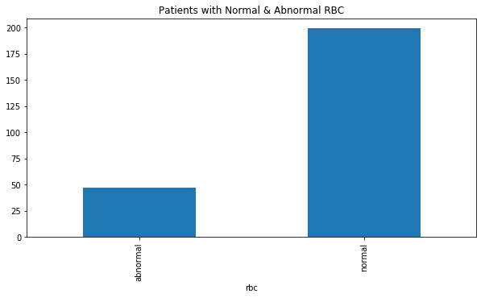

```python
data=ckdf.groupby('rbc').rbc.count().plot(kind="bar",figsize=(10, 5),title="Patients with Normal & Abnormal RBC") #grouped by rbc and thier count
```

# 7. Display maximum blood pressure having Chronic Kidney Disease(CKD).

```
class
ckd       180.0
notckd     80.0
Name: bp, dtype: float64
```

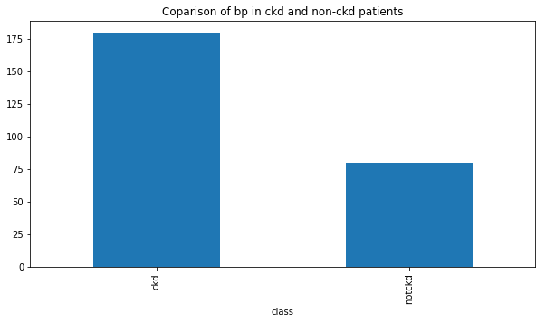

```python
data = ckdf.groupby('class')['bp'].max()
print data
data.plot(kind="bar",figsize=(10, 5),title="Coparison of bp in ckd and non-ckd patients")
```

```python
# The max blood presure for ckd in 180.0 and max blood pressure for notckd is 80.0
```

```python
ckdf.loc[ckdf['class'].isin(['ckd'])]['bp'].max() # Command for highest blood pressure in all ckd patients.
```

```
180.0
```

# 8. Create a csv file of cleaned data in dataframe with name "clean_chronic_kidney_disease.csv"

```python
ckdf.to_csv('clean_chronic_kidney_disease.csv', sep=',')
```